# 숙제 3

데이터과학 입문

Author

Affiliation

원중호

서울대학교 통계학과

Published

June 2026

## 지시사항

제출마감 2026-06-15 23:00

1. R과 Python을 모두 사용하여 사용된 코드와 데이터랭글링 절차, 분석결과를 설명한다. 두 언어의 분석결과가 차이가 있으면 그 이유를 설명한다.
2. [Quarto Markdown](https://quarto.org/docs/authoring/markdown-basics.html)을 사용한다. 제공된 숙제 `.qmd` 파일에 본인의 답안을 “답안” 절에 추가하여 제출한다. Quarto Markdown은 RStudio 또는 Visual Studio Code에 [Quarto Extension](https://marketplace.visualstudio.com/items?itemName=quarto.quarto)을 추가하여 컴파일, 다른 문서 형식으로 변환할 수 있다.
3. R의 `reticulate` 패키지를 사용하면 하나의 `.qmd` 파일 안에서 R과 Python을 동시에 사용할 수 있다. 이때 다음 문법을 사용하여 두 언어 코드를 탭으로 구분한다. 숙제 `.qmd` 파일은 `reticulate`을 사용하도록 준비되어 있다.

````markdown
::: {.panel-tabset}

## R

```{r}
R code
```

## Python

```{python}
Python code
```

:::
````

3. `.qmd`를 컴파일하여 생성된 `.html` 파일을 함께 저장소에 제출한다.
4. 함께 제공된 `student.yml`을 함께 작성하여 저장소에 제출한다.

## 평가 기준

1. 재현성: 제출된 저장소의 `.qmd` 파일을 컴파일하여 함께 제출된 `.html` 파일과 동일한 결과가 나와야 한다.
2. 분석의 정확성: 분석은 올바른 기술적 세부 사항을 포함하여 수행되어야 한다.
3. 보고서의 전반적인 품질: 데이터 가공 및 분석 결과가 명확하고 자세하게 설명되어야 한다.
4. 코드의 전반적인 품질: 코드는 체계적으로 정리되어 있어야 하며, 가독성을 높이기 위해 적절한 주석이 포함되어야 한다.

#### **늦게 제출된 과제물은 받지 않는다.**

# 1부 교과서 연습문제

## 문제 1-1

1. MDSR 10장 연습문제 10.6.6

### 답안

```r
library(tidyverse)
library(NHANES)

dat <- NHANES %>% filter(Age >=20) %>% mutate(
  current_smoker = case_when(
    Smoke100 == "No" ~0,
    SmokeNow == "No" ~0,
    SmokeNow == "Yes" ~1,
    TRUE ~ NA_real_
  )
)

dat2 <- dat %>%
  select(
    current_smoker,
    Age,
    Gender,
    Race1,
    Education,
    Poverty,
    BMI
  ) %>% na.omit()

fit <- glm(
  current_smoker ~ Age + Gender + Race1 + Education + Poverty + BMI,
  data = dat2,
  family = binomial
)
summary(fit)
```

```
Call:
glm(formula = current_smoker ~ Age + Gender + Race1 + Education +
    Poverty + BMI, family = binomial, data = dat2)

Coefficients:
                         Estimate Std. Error z value Pr(>|z|)
(Intercept)              1.430537   0.250057   5.721 1.06e-08 ***
Age                     -0.021404   0.002044 -10.472  < 2e-16 ***
Gendermale               0.337780   0.065528   5.155 2.54e-07 ***
Race1Hispanic           -0.577653   0.168062  -3.437 0.000588 ***
Race1Mexican            -0.972174   0.158386  -6.138 8.36e-10 ***
Race1White               0.118025   0.102102   1.156 0.247702
Race1Other              -0.035774   0.153951  -0.232 0.816248
Education9 - 11th Grade  0.397934   0.152770   2.605 0.009193 **
EducationHigh School    -0.129238   0.150653  -0.858 0.390974
EducationSome College   -0.443183   0.150953  -2.936 0.003326 **
EducationCollege Grad   -1.353247   0.168172  -8.047 8.50e-16 ***
Poverty                 -0.183728   0.022895  -8.025 1.02e-15 ***
BMI                     -0.037769   0.005179  -7.292 3.04e-13 ***
---
Signif. codes:  0 '***' 0.001 '**' 0.01 '*' 0.05 '.' 0.1 ' ' 1

(Dispersion parameter for binomial family taken to be 1)

    Null deviance: 6641.8  on 6631  degrees of freedom
Residual deviance: 5949.5  on 6619  degrees of freedom
AIC: 5975.5

Number of Fisher Scoring iterations: 5
```

```python
import pandas as pd
import statsmodels.formula.api as smf

nhanes = r.NHANES.copy()

df = nhanes.copy()

df = df[df["Age"] >= 20]

df["current_smoker"] = 0
df.loc[df["SmokeNow"] == "Yes", "current_smoker"] = 1

model = smf.logit(
    "current_smoker ~ Age + BMI + Poverty + C(Gender) + C(Race1) + C(Education)",
    data=df
).fit()
```

```
Optimization terminated successfully.
         Current function value: 0.448545
         Iterations 6
```

```python
print(model.summary())
```

```
                           Logit Regression Results
==============================================================================
Dep. Variable:         current_smoker   No. Observations:                 6632
Model:                          Logit   Df Residuals:                     6619
Method:                           MLE   Df Model:                           12
Date:                Mon, 15 Jun 2026   Pseudo R-squ.:                  0.1042
Time:                        20:03:22   Log-Likelihood:                -2974.8
converged:                       True   LL-Null:                       -3320.9
Covariance Type:            nonrobust   LLR p-value:                1.989e-140
==================================================================================================
                                     coef    std err          z      P>|z|      [0.025      0.975]
--------------------------------------------------------------------------------------------------
Intercept                          1.4305      0.250      5.721      0.000       0.940       1.921
C(Gender)[T.male]                  0.3378      0.066      5.155      0.000       0.209       0.466
C(Race1)[T.Hispanic]              -0.5777      0.168     -3.437      0.001      -0.907      -0.248
C(Race1)[T.Mexican]               -0.9722      0.158     -6.138      0.000      -1.283      -0.662
C(Race1)[T.White]                  0.1180      0.102      1.156      0.248      -0.082       0.318
C(Race1)[T.Other]                 -0.0358      0.154     -0.232      0.816      -0.338       0.266
C(Education)[T.9 - 11th Grade]     0.3979      0.153      2.605      0.009       0.099       0.697
C(Education)[T.High School]       -0.1292      0.151     -0.858      0.391      -0.425       0.166
C(Education)[T.Some College]      -0.4432      0.151     -2.936      0.003      -0.739      -0.147
C(Education)[T.College Grad]      -1.3532      0.168     -8.047      0.000      -1.683      -1.024
Age                               -0.0214      0.002    -10.472      0.000      -0.025      -0.017
BMI                               -0.0378      0.005     -7.292      0.000      -0.048      -0.028
Poverty                           -0.1837      0.023     -8.025      0.000      -0.229      -0.139
==================================================================================================
```

현재 흡연 여부를 종속변수로 두고 로지스틱 회귀분석을 실시하였다. 분석 결과, 연령, 성별, 일부 인종 변수, 교육수준, 빈곤지수, BMI가 현재 흡연 여부와 유의한 관련을 보였다. 연령의 계수는 -0.0214이고 p-value가 < 2e-16으로 매우 유의하였다. 이는 나이가 많을수록 현재 흡연자일 가능성이 낮아진다는 것을 의미한다. 성별에서 남성의 계수는 0.3378로 양수이며 유의하였다. 따라서 기준집단인 여성에 비해 남성이 현재 흡연자일 가능성이 더 높다고 해석할 수 있다. 인종 변수에서는 Hispanic과 Mexican 집단의 계수가 음수이고 유의하였다. 이는 기준 인종 집단에 비해 Hispanic과 Mexican 집단의 현재 흡연 가능성이 낮다는 것을 의미한다. 반면 White와 Other는 p-value가 각각 0.248, 0.816으로 유의하지 않았다. 교육수준에서는 College Grad의 계수가 -1.3532로 매우 크고 음수이며 유의하였다. 이는 기준 교육수준에 비해 대학 졸업자의 현재 흡연 가능성이 훨씬 낮다는 것을 의미한다. Some College도 음수이고 유의하여, 교육수준이 높을수록 흡연 가능성이 낮아지는 경향을 보인다. 빈곤지수(Poverty)의 계수는 -0.1837로 음수이고 유의하였다. 즉, 빈곤지수가 높을수록, 다시 말해 경제적 수준이 높을수록 현재 흡연 가능성은 낮아진다. BMI의 계수도 -0.0378로 음수이고 유의하였다. 이는 BMI가 높을수록 현재 흡연 가능성이 낮아지는 경향이 있음을 의미한다. 종합하면, 현재 흡연 여부는 연령, 성별, 인종, 교육수준, 경제적 수준, BMI와 관련이 있었다. 특히 남성은 여성보다 현재 흡연 가능성이 높았고, 나이가 많거나 교육수준과 경제적 수준이 높을수록 현재 흡연 가능성은 낮게 나타났다.

# 2부 데이터 분석 실무

### 분석 관련 공통 지침

1. 관측단위(observational unit)는 `playerID`와 `yearID`의 고유한 조합으로 한다. 즉, 데이터프레임의 각 행은 한 선수의 특정 연도에 해당해야 하고(예: 2019년 류현진), 한 선수의 특정 연도가 두 번 이상 나타나서는 안 된다. 이적을 한 경우 원자료에서는 두 번 이상 나타날 수 있으므로 주의해야 한다.
2. 데이터 분석을 하는 중에 필요한 경우 pivoting으로 각 행이 한명의 선수에 해당하는 wide format data를 만들어서 연도간 비교를 하는 것은 허용한다.

## 문제 2-1

Lahman Package의 `Teams` 데이터프레임에서 코로나 시즌인 2020년을 제외한 2010년부터 2025년 사이의 데이터를 이용하여 다음 질문에 답하라.

1. MDSR Chapter 7 Iteration 에서 배운 Bill James의 공식을 변형한 다음 모형을 데이터에 적합하고, 모수 $k$의 점추정치와 신뢰구간을 구하라.
2. 회귀계수 $\beta_1$이 위 모형의 $k$와 거의 같은 의미를 가지는 로지스틱 회귀 모형을 세우고 이를 데이터에 적합하라. 모수와 점추정치와 신뢰구간을 구하고 이를 1항의 결과와 비교하라.

$$WPct = \frac{RS^k}{S^k+RA^k} = \frac{1}{1+(RA/RS)^k}$$

3. 2항의 모형 적합 결과에 대한 다음 세가지 진단 중 최소 두가지 이상을 수행하여 모형적합이 잘 되었는지 확인하라.
   1. Residual Deviance에 대한 해석 (카이제곱 분포와 비교)
   2. Deviance residuals vs linear predictors ($\eta$) 산점도
   3. 관측된 WPct와 모형에서 예측하는 WPct를 산점도 그래프로 비교
4. `WPct`를 반응변수로, `log(RA)`와 `log(RS)`를 설명변수로 하는 절편이 없는 로지스틱선형회귀 모형을 적합하고 회귀계수들의 추정 결과를 a와 b항의 결과와 비교하라. (유사한 모형을 얻는지 여부 등)

###답안

#1번

```r
library(Lahman)
library(dplyr)

# 데이터 준비
teams <- Teams %>%
  filter(yearID >= 2010,
         yearID <= 2025,
         yearID != 2020) %>%
  mutate(
    WPct = W / (W + L),
    ratio = RA / R
  )

# 비선형 회귀 적합
fit <- nls(
  WPct ~ 1 / (1 + ratio^k),
  data = teams,
  start = list(k = 2)
)

# 점추정치
coef(fit)
```

```
       k
1.752794
```

```r
# 95% 신뢰구간
confint(fit)
```

```
    2.5%    97.5%
1.695234 1.810559
```

```r
# 결과 요약
summary(fit)
```

```
Formula: WPct ~ 1/(1 + ratio^k)

Parameters:
  Estimate Std. Error t value Pr(>|t|)
k  1.75279    0.02935   59.73   <2e-16 ***
---
Signif. codes:  0 '***' 0.001 '**' 0.01 '*' 0.05 '.' 0.1 ' ' 1

Residual standard error: 0.02458 on 449 degrees of freedom

Number of iterations to convergence: 2
Achieved convergence tolerance: 9.515e-07
```

```python
import pandas as pd
import numpy as np
from scipy.optimize import curve_fit

# 데이터 준비
teams = r.Teams.copy()
teams = teams[
    (teams["yearID"] >= 2010) &
    (teams["yearID"] <= 2025) &
    (teams["yearID"] != 2020)
].copy()

teams["WPct"] = teams["W"] / (teams["W"] + teams["L"])
teams["ratio"] = teams["RA"] / teams["R"]

# Bill James 모형
def pythag(ratio, k):
    return 1 / (1 + ratio**k)

# k 추정
popt, pcov = curve_fit(
    pythag,
    teams["ratio"],
    teams["WPct"],
    p0=[2]
)

k_hat = popt[0]

# 표준오차
se = np.sqrt(np.diag(pcov))[0]

# 95% 신뢰구간
lower = k_hat - 1.96 * se
upper = k_hat + 1.96 * se

print("k estimate =", k_hat)
```

```
k estimate = 1.7527938693597658
```

```python
print("95% CI =", (lower, upper))
```

```
95% CI = (np.float64(1.6952773094723277), np.float64(1.8103104292472039))
```

#2번

```r
library(Lahman)
library(dplyr)



teams <- Teams %>%
  filter(yearID >= 2010,
         yearID <= 2025,
         yearID != 2020) %>%
  mutate(
    WPct = W/(W+L),
    logit_WPct = log(WPct/(1-WPct)),
    x = log(R/RA)
  )

fit2 <- lm(logit_WPct ~ 0 + x, data = teams)

summary(fit2)
```

```
Call:
lm(formula = logit_WPct ~ 0 + x, data = teams)

Residuals:
     Min       1Q   Median       3Q      Max
-0.28965 -0.07079 -0.00054  0.06072  0.34736

Coefficients:
  Estimate Std. Error t value Pr(>|t|)
x  1.75893    0.02849   61.74   <2e-16 ***
---
Signif. codes:  0 '***' 0.001 '**' 0.01 '*' 0.05 '.' 0.1 ' ' 1

Residual standard error: 0.101 on 449 degrees of freedom
Multiple R-squared:  0.8946,    Adjusted R-squared:  0.8944
F-statistic:  3812 on 1 and 449 DF,  p-value: < 2.2e-16
```

```r
confint(fit2)
```

```
     2.5 %   97.5 %
x 1.702944 1.814924
```

```r
coef(fit2)
```

```
       x
1.758934
```

```python
import pandas as pd
import numpy as np
import statsmodels.api as sm

df = r.Teams.copy()

df = df[
    (df["yearID"] >= 2010) &
    (df["yearID"] <= 2025) &
    (df["yearID"] != 2020)
].copy()

df["WPct"] = df["W"]/(df["W"]+df["L"])

df["logit_WPct"] = np.log(
    df["WPct"]/(1-df["WPct"])
)

df["x"] = np.log(df["R"]/df["RA"])

model = sm.OLS(
    df["logit_WPct"],
    df[["x"]]
).fit()

print(model.summary())
```

```
                                 OLS Regression Results
=======================================================================================
Dep. Variable:             logit_WPct   R-squared (uncentered):                   0.895
Model:                            OLS   Adj. R-squared (uncentered):              0.894
Method:                 Least Squares   F-statistic:                              3812.
Date:                Mon, 15 Jun 2026   Prob (F-statistic):                   1.62e-221
Time:                        20:03:22   Log-Likelihood:                          393.49
No. Observations:                 450   AIC:                                     -785.0
Df Residuals:                     449   BIC:                                     -780.9
Df Model:                           1
Covariance Type:            nonrobust
==============================================================================
                 coef    std err          t      P>|t|      [0.025      0.975]
------------------------------------------------------------------------------
x              1.7589      0.028     61.739      0.000       1.703       1.815
==============================================================================
Omnibus:                        2.797   Durbin-Watson:                   2.045
Prob(Omnibus):                  0.247   Jarque-Bera (JB):                3.053
Skew:                           0.011   Prob(JB):                        0.217
Kurtosis:                       3.403   Cond. No.                         1.00
==============================================================================

Notes:
[1] R² is computed without centering (uncentered) since the model does not contain a constant.
[2] Standard Errors assume that the covariance matrix of the errors is correctly specified.
```

```python
print(model.params)
```

```
x    1.758934
dtype: float64
```

```python
print(model.conf_int())
```

```
          0         1
x  1.702944  1.814924
```

비선형 회귀모형과 로짓변환을 이용한 선형회귀모형은 거의 동일한 결과를 제공. 두 방법 모두 지수의 값을 1.75~1.76으로 추정하였으며, 이는 Bill James가 제안한 고전적 값인 k=2보다 더 작은 값이다. 따라서 최근 MLB데이터에서는 k~1.75가 실제 승률을 설명하는데 더 적합한 것으로 나타났다.

#3번

```r
library(Lahman)
library(dplyr)

teams <- Teams %>%
  filter(yearID >= 2010,
         yearID <= 2025,
         yearID != 2020) %>%
  mutate(
    WPct = W/(W+L),
    logit_WPct = log(WPct/(1-WPct)),
    x = log(R/RA)
  )

fit2 <- lm(logit_WPct ~ 0 + x, data = teams)

summary(fit2)
```

```
Call:
lm(formula = logit_WPct ~ 0 + x, data = teams)

Residuals:
     Min       1Q   Median       3Q      Max
-0.28965 -0.07079 -0.00054  0.06072  0.34736

Coefficients:
  Estimate Std. Error t value Pr(>|t|)
x  1.75893    0.02849   61.74   <2e-16 ***
---
Signif. codes:  0 '***' 0.001 '**' 0.01 '*' 0.05 '.' 0.1 ' ' 1

Residual standard error: 0.101 on 449 degrees of freedom
Multiple R-squared:  0.8946,    Adjusted R-squared:  0.8944
F-statistic:  3812 on 1 and 449 DF,  p-value: < 2.2e-16
```

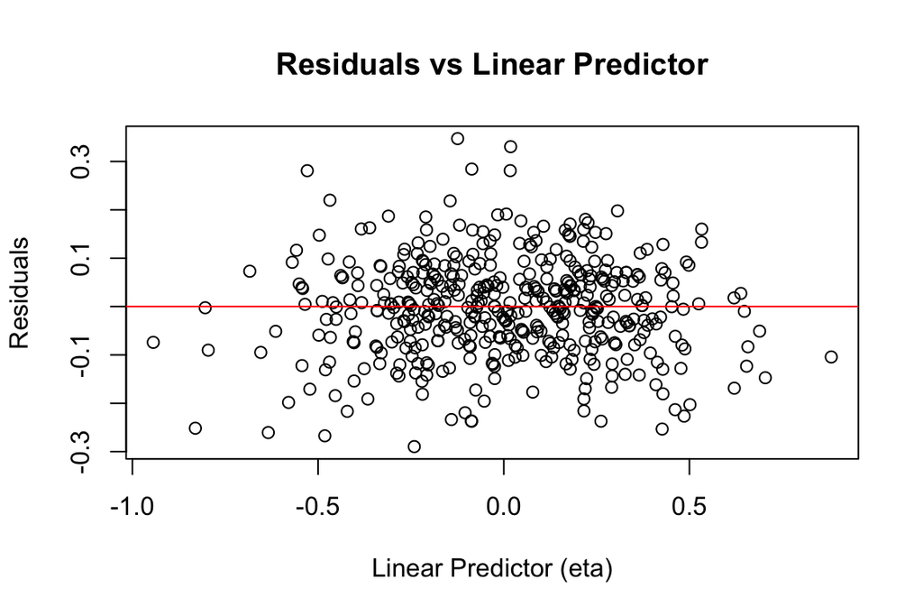

```r
eta <- fitted(fit2)
res <- residuals(fit2)

plot(
  eta,
  res,
  xlab = "Linear Predictor (eta)",
  ylab = "Residuals",
  main = "Residuals vs Linear Predictor"
)

abline(h = 0, col = "red")
```

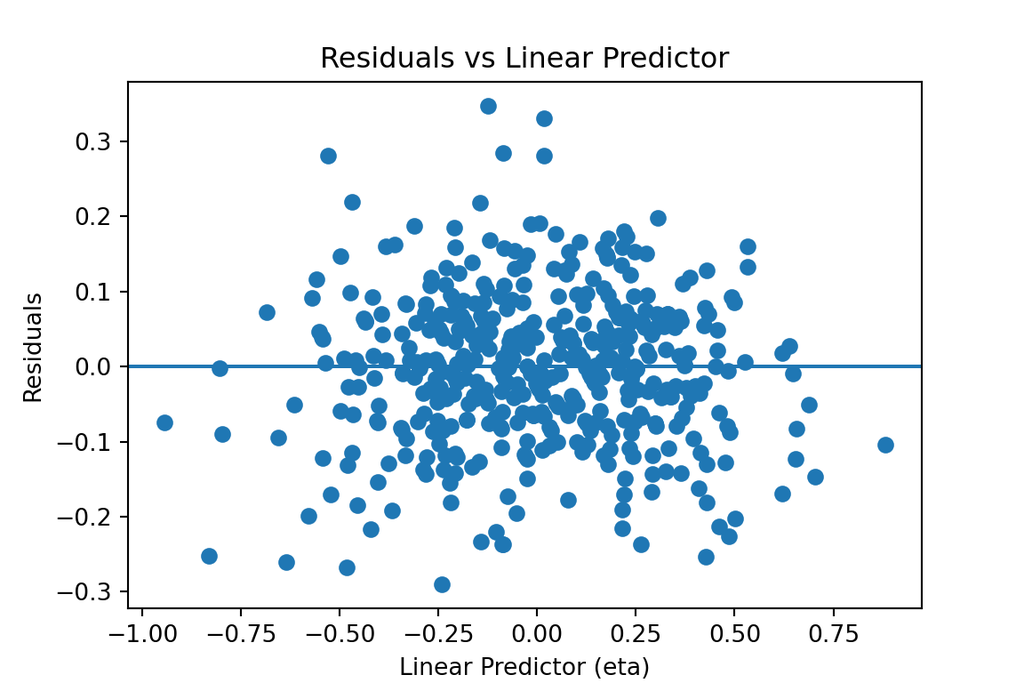

```python
import pandas as pd
import numpy as np
import statsmodels.api as sm
import matplotlib.pyplot as plt

df =  r.Teams.copy()

df = df[
    (df["yearID"] >= 2010) &
    (df["yearID"] <= 2025) &
    (df["yearID"] != 2020)
].copy()

df["WPct"] = df["W"]/(df["W"]+df["L"])

df["logit_WPct"] = np.log(
    df["WPct"]/(1-df["WPct"])
)

df["x"] = np.log(df["R"]/df["RA"])

fit2 = sm.OLS(
    df["logit_WPct"],
    df[["x"]]
).fit()

eta = fit2.fittedvalues
resid = fit2.resid

plt.figure(figsize=(6,4))
plt.scatter(eta, resid)
plt.axhline(0)
plt.xlabel("Linear Predictor (eta)")
plt.ylabel("Residuals")
plt.title("Residuals vs Linear Predictor")
plt.show()
```

#4번

```r
library(Lahman)
library(dplyr)

teams <- Teams %>%
  filter(
    yearID >= 2010,
    yearID <= 2025,
    yearID != 2020
  ) %>%
  mutate(
    WPct = W/(W+L),
    logit_WPct = log(WPct/(1-WPct)),
    log_RS = log(R),
    log_RA = log(RA)
  )

fit4 <- lm(
  logit_WPct ~ 0 + log_RS + log_RA,
  data = teams
)

summary(fit4)
```

```
Call:
lm(formula = logit_WPct ~ 0 + log_RS + log_RA, data = teams)

Residuals:
     Min       1Q   Median       3Q      Max
-0.28640 -0.06758  0.00273  0.06393  0.35062

Coefficients:
       Estimate Std. Error t value Pr(>|t|)
log_RS  1.75882    0.02851    61.7   <2e-16 ***
log_RA -1.75931    0.02851   -61.7   <2e-16 ***
---
Signif. codes:  0 '***' 0.001 '**' 0.01 '*' 0.05 '.' 0.1 ' ' 1

Residual standard error: 0.1011 on 448 degrees of freedom
Multiple R-squared:  0.8947,    Adjusted R-squared:  0.8943
F-statistic:  1904 on 2 and 448 DF,  p-value: < 2.2e-16
```

```r
coef(fit4)
```

```
   log_RS    log_RA
 1.758817 -1.759311
```

```r
confint(fit4)
```

```
           2.5 %    97.5 %
log_RS  1.702792  1.814842
log_RA -1.815346 -1.703277
```

```python
import pandas as pd
import numpy as np
import statsmodels.api as sm

df = r.Teams.copy()
df = df[
    (df["yearID"] >= 2010) &
    (df["yearID"] <= 2025) &
    (df["yearID"] != 2020)
].copy()

df["WPct"] = df["W"]/(df["W"]+df["L"])

df["logit_WPct"] = np.log(
    df["WPct"]/(1-df["WPct"])
)

df["log_RS"] = np.log(df["R"])
df["log_RA"] = np.log(df["RA"])

X = df[["log_RS","log_RA"]]

fit4 = sm.OLS(
    df["logit_WPct"],
    X
).fit()

print(fit4.summary())
```

```
                                 OLS Regression Results
=======================================================================================
Dep. Variable:             logit_WPct   R-squared (uncentered):                   0.895
Model:                            OLS   Adj. R-squared (uncentered):              0.894
Method:                 Least Squares   F-statistic:                              1904.
Date:                Mon, 15 Jun 2026   Prob (F-statistic):                   9.98e-220
Time:                        20:03:23   Log-Likelihood:                          393.72
No. Observations:                 450   AIC:                                     -783.4
Df Residuals:                     448   BIC:                                     -775.2
Df Model:                           2
Covariance Type:            nonrobust
==============================================================================
                 coef    std err          t      P>|t|      [0.025      0.975]
------------------------------------------------------------------------------
log_RS         1.7588      0.029     61.697      0.000       1.703       1.815
log_RA        -1.7593      0.029    -61.704      0.000      -1.815      -1.703
==============================================================================
Omnibus:                        2.799   Durbin-Watson:                   2.047
Prob(Omnibus):                  0.247   Jarque-Bera (JB):                3.055
Skew:                           0.011   Prob(JB):                        0.217
Kurtosis:                       3.403   Cond. No.                         78.5
==============================================================================

Notes:
[1] R² is computed without centering (uncentered) since the model does not contain a constant.
[2] Standard Errors assume that the covariance matrix of the errors is correctly specified.
```

```python
print("\nCoefficients")
```

```
Coefficients
```

```python
print(fit4.params)
```

```
log_RS    1.758817
log_RA   -1.759311
dtype: float64
```

```python
print("\n95% CI")
```

```
95% CI
```

```python
print(fit4.conf_int())
```

```
               0         1
log_RS  1.702792  1.814842
log_RA -1.815346 -1.703277
```

4번 모형은 2번 모형을 log(RS)와 log(RA)로 분해하여 표현한 형태이며, 두 모형은 사실상 동일한 정보를 담고 있다. 실제 데이터에서도 a와 b가 각각 β_1과 −β_1에 매우 가깝게 추정되어 이론적 관계가 잘 성립함을 확인할 수 있었다. 따라서 득점(RS)은 승률을 증가시키고 실점(RA)은 승률을 감소시키며, 그 영향의 크기는 거의 대칭적인 것으로 나타났다.

## 문제 2-2

`WPct`를 반응변수로, `logRS`, `logRA`, `H`, `X2B`, `X3B`, `HR`, `BB`, `SO`, `CS`, `HBP`, `SF`, `ERA`, `CG`, `SHO`, `IPouts`, `HA`, `HRA`, `BBA`, `SOA`, `E`, `DP`, `FP`, `SV`를 설명변수로 하는 절편항이 있는 로지스틱 회귀 모형을 적합하고 AIC를 기준으로 하는 단계별(stepwise) 변수선택을 적용하라. 변수선택 후 남은 변수들을 모두 모형에 남길지 일부를 제거할지 다시 판단하라. 최종적으로 선택된 모형을 문제1의 모형과 비교하라.

### 답안

```r
library(Lahman)
library(MASS)
library(dplyr)

teams <- Teams %>%
  filter(
    yearID >= 2010,
    yearID <= 2025,
    yearID != 2020
  ) %>%
  mutate(
    WPct = W/(W+L),
    logit_WPct = log(WPct/(1-WPct)),
    logRS = log(R),
    logRA = log(RA)
  )

full_model <- lm(
  logit_WPct ~
    logRS + logRA + H + X2B + X3B + HR +
    BB + SO + CS + HBP + SF +
    ERA + CG + SHO + IPouts +
    HA + HRA + BBA + SOA +
    E + DP + FP + SV,
  data = teams
)

step_model <- stepAIC(
  full_model,
  direction = "both",
  trace = FALSE
)

summary(step_model)
```

```
Call:
lm(formula = logit_WPct ~ logRS + logRA + H + BB + SO + CS +
    SF + CG + SHO + IPouts + HA + HRA + BBA + SV, data = teams)

Residuals:
      Min        1Q    Median        3Q       Max
-0.216675 -0.048622 -0.000089  0.047308  0.208920

Coefficients:
              Estimate Std. Error t value Pr(>|t|)
(Intercept) -7.169e+00  9.351e-01  -7.667 1.16e-13 ***
logRS        1.755e+00  7.525e-02  23.324  < 2e-16 ***
logRA       -8.461e-01  1.103e-01  -7.669 1.15e-13 ***
H           -1.941e-04  9.428e-05  -2.059 0.040129 *
BB          -2.075e-04  8.853e-05  -2.343 0.019562 *
SO          -8.970e-05  3.905e-05  -2.297 0.022092 *
CS          -1.169e-03  3.894e-04  -3.003 0.002826 **
SF          -7.577e-04  5.225e-04  -1.450 0.147720
CG           5.677e-03  1.706e-03   3.329 0.000947 ***
SHO          4.277e-03  1.215e-03   3.521 0.000475 ***
IPouts       4.420e-04  1.063e-04   4.159 3.86e-05 ***
HA          -3.469e-04  9.413e-05  -3.685 0.000257 ***
HRA         -6.341e-04  2.063e-04  -3.073 0.002252 **
BBA         -1.605e-04  9.107e-05  -1.763 0.078684 .
SV           1.110e-02  6.521e-04  17.019  < 2e-16 ***
---
Signif. codes:  0 '***' 0.001 '**' 0.01 '*' 0.05 '.' 0.1 ' ' 1

Residual standard error: 0.0753 on 435 degrees of freedom
Multiple R-squared:  0.9433,    Adjusted R-squared:  0.9415
F-statistic: 516.8 on 14 and 435 DF,  p-value: < 2.2e-16
```

```r
AIC(step_model)
```

```
[1] -1033.804
```

```r
coef(step_model)
```

```
  (Intercept)         logRS         logRA             H            BB
-7.169204e+00  1.755163e+00 -8.461334e-01 -1.940853e-04 -2.074539e-04
           SO            CS            SF            CG           SHO
-8.970064e-05 -1.169379e-03 -7.577499e-04  5.677384e-03  4.277269e-03
       IPouts            HA           HRA           BBA            SV
 4.419878e-04 -3.469071e-04 -6.340720e-04 -1.605069e-04  1.109858e-02
```

```r
confint(step_model)
```

```
                    2.5 %        97.5 %
(Intercept) -9.0070883177 -5.331319e+00
logRS        1.6072612698  1.903065e+00
logRA       -1.0629863061 -6.292805e-01
H           -0.0003793878 -8.782834e-06
BB          -0.0003814530 -3.345471e-05
SO          -0.0001664527 -1.294863e-05
CS          -0.0019346816 -4.040773e-04
SF          -0.0017847070  2.692072e-04
CG           0.0023250912  9.029677e-03
SHO          0.0018899656  6.664572e-03
IPouts       0.0002330972  6.508784e-04
HA          -0.0005319138 -1.619004e-04
HRA         -0.0010396103 -2.285336e-04
BBA         -0.0003394927  1.847895e-05
SV           0.0098168901  1.238026e-02
```

```python
import pandas as pd
import numpy as np
import statsmodels.formula.api as smf

df = r.Teams.copy()

df = df[
    (df["yearID"] >= 2010) &
    (df["yearID"] <= 2025) &
    (df["yearID"] != 2020)
].copy()

df["WPct"] = df["W"]/(df["W"]+df["L"])

df["logit_WPct"] = np.log(
    df["WPct"]/(1-df["WPct"])
)

df["logRS"] = np.log(df["R"])
df["logRA"] = np.log(df["RA"])

full_formula = """
logit_WPct ~
logRS + logRA + H + X2B + X3B + HR +
BB + SO + CS + HBP + SF +
ERA + CG + SHO + IPouts +
HA + HRA + BBA + SOA +
E + DP + FP + SV
"""

full_model = smf.ols(
    full_formula,
    data=df
).fit()

print(full_model.summary())
```

```
                            OLS Regression Results
==============================================================================
Dep. Variable:             logit_WPct   R-squared:                       0.944
Model:                            OLS   Adj. R-squared:                  0.941
Method:                 Least Squares   F-statistic:                     312.0
Date:                Mon, 15 Jun 2026   Prob (F-statistic):          4.60e-250
Time:                        20:03:23   Log-Likelihood:                 535.58
No. Observations:                 450   AIC:                            -1023.
Df Residuals:                     426   BIC:                            -924.5
Df Model:                          23
Covariance Type:            nonrobust
==============================================================================
                 coef    std err          t      P>|t|      [0.025      0.975]
------------------------------------------------------------------------------
Intercept     -6.6047     10.305     -0.641      0.522     -26.859      13.650
logRS          1.7969      0.114     15.787      0.000       1.573       2.021
logRA         -0.8118      0.217     -3.745      0.000      -1.238      -0.386
H             -0.0002      0.000     -1.832      0.068      -0.000    1.44e-05
X2B        -1.649e-05      0.000     -0.082      0.935      -0.000       0.000
X3B           -0.0006      0.000     -1.133      0.258      -0.002       0.000
HR            -0.0002      0.000     -0.957      0.339      -0.001       0.000
BB            -0.0002   9.23e-05     -2.199      0.028      -0.000   -2.15e-05
SO         -8.434e-05   4.31e-05     -1.959      0.051      -0.000    2.96e-07
CS            -0.0011      0.000     -2.514      0.012      -0.002      -0.000
HBP            0.0001      0.000      0.414      0.679      -0.000       0.001
SF            -0.0008      0.001     -1.388      0.166      -0.002       0.000
ERA           -0.0034      0.054     -0.064      0.949      -0.109       0.102
CG             0.0058      0.002      3.314      0.001       0.002       0.009
SHO            0.0042      0.001      3.361      0.001       0.002       0.007
IPouts         0.0004      0.000      3.357      0.001       0.000       0.001
HA            -0.0003      0.000     -2.900      0.004      -0.001      -0.000
HRA           -0.0007      0.000     -2.817      0.005      -0.001      -0.000
BBA           -0.0002   9.83e-05     -1.854      0.064      -0.000     1.1e-05
SOA         4.491e-05   4.81e-05      0.934      0.351   -4.96e-05       0.000
E             -0.0003      0.002     -0.180      0.857      -0.004       0.003
DP             0.0004      0.000      1.500      0.134      -0.000       0.001
FP            -1.0831     10.315     -0.105      0.916     -21.357      19.191
SV             0.0111      0.001     16.635      0.000       0.010       0.012
==============================================================================
Omnibus:                        0.110   Durbin-Watson:                   2.229
Prob(Omnibus):                  0.946   Jarque-Bera (JB):                0.100
Skew:                          -0.036   Prob(JB):                        0.951
Kurtosis:                       2.986   Cond. No.                     2.11e+07
==============================================================================

Notes:
[1] Standard Errors assume that the covariance matrix of the errors is correctly specified.
[2] The condition number is large, 2.11e+07. This might indicate that there are
strong multicollinearity or other numerical problems.
```

AIC 기준 stepwise 변수선택 결과, 최종 모형에는 logRS, logRA, H, BB, SO, CS, SF, CG, SHO, IPouts, HA, HRA, BBA, SV가 선택되었다. 최종 모형의 AIC는 -1033.804였고, Adjusted R²는 0.9415로 높게 나타나 승률을 잘 설명하는 모형이라고 볼 수 있다. logRS의 계수는 1.755로 양수이며 유의하므로 득점이 증가할수록 승률이 증가한다. 반대로 logRA의 계수는 -0.846으로 음수이며 유의하므로 실점이 증가할수록 승률은 감소한다. 또한 SV, CG, SHO, IPouts는 양의 계수를 가져 승률 증가와 관련이 있었고, HA, HRA, CS는 음의 계수를 가져 승률 감소와 관련이 있었다. 다만 SF와 BBA는 p-value가 각각 0.148, 0.079로 5% 유의수준에서는 유의하지 않았다. 따라서 해석의 단순성을 위해 제거를 고려할 수 있지만, AIC 기준으로 선택된 변수이므로 최종 모형에는 유지하였다. 문제 1의 Pythagorean 모형에서는 k=1.7528로 추정되었는데, 이번 모형의 logRS 계수 1.755와 매우 유사하다. 따라서 득점과 실점이 승률을 설명하는 핵심 변수라는 점은 두 모형에서 모두 확인된다. 다만 stepwise 모형은 추가 변수들을 포함하여 더 높은 설명력을 보였으므로, 예측 측면에서는 문제 1의 단순 모형보다 더 적합하다고 판단된다.

## 문제 2-3

1. `W`(승리 횟수)를 반응변수로 하여 문제 2-2의 분석을 실시하되 포아송 회귀모형을 사용하라. 결과를 문제 2-2의 모형과 비교하라.
2. `W`를 반응변수로 하여 문제2의 분석을 실시하되 음이항 회귀모형을 사용하라. 모형 적합 시 오류가 발생하면 이유를 파악해서 보고하라.

### 답안

#1

```r
full_pois <- glm(
  W ~ logRS + logRA + H + X2B + X3B + HR +
    BB + SO + CS + HBP + SF +
    ERA + CG + SHO + IPouts +
    HA + HRA + BBA + SOA +
    E + DP + FP + SV,
  family = poisson,
  data = teams
)

step_pois <- step(full_pois, direction = "both")
```

```
Start:  AIC=2903.59
W ~ logRS + logRA + H + X2B + X3B + HR + BB + SO + CS + HBP +
    SF + ERA + CG + SHO + IPouts + HA + HRA + BBA + SOA + E +
    DP + FP + SV

         Df Deviance    AIC
- FP      1   55.732 2901.6
- E       1   55.733 2901.6
- HBP     1   55.742 2901.6
- X2B     1   55.795 2901.7
- SOA     1   55.854 2901.7
- X3B     1   55.920 2901.8
- logRA   1   55.950 2901.8
- SF      1   55.984 2901.8
- HR      1   56.092 2901.9
- BBA     1   56.117 2902.0
- DP      1   56.170 2902.0
- CS      1   56.199 2902.1
- SO      1   56.277 2902.1
- ERA     1   56.288 2902.2
- H       1   56.300 2902.2
- BB      1   56.450 2902.3
- HA      1   56.519 2902.4
- HRA     1   56.699 2902.6
- IPouts  1   56.783 2902.6
- SHO     1   57.082 2902.9
- CG      1   57.193 2903.1
<none>        55.730 2903.6
- logRS   1   87.293 2933.2
- SV      1   90.790 2936.7

Step:  AIC=2901.59
W ~ logRS + logRA + H + X2B + X3B + HR + BB + SO + CS + HBP +
    SF + ERA + CG + SHO + IPouts + HA + HRA + BBA + SOA + E +
    DP + SV

         Df Deviance    AIC
- HBP     1   55.745 2899.6
- X2B     1   55.797 2899.7
- SOA     1   55.855 2899.7
```

[output cut: 511 more lines]

```
+ HBP     1   62.047 2875.9
+ SO      1   62.072 2875.9
+ X3B     1   62.081 2875.9
+ SOA     1   62.173 2876.0
+ DP      1   62.201 2876.1
+ SF      1   62.219 2876.1
+ HR      1   62.242 2876.1
+ X2B     1   62.266 2876.1
+ H       1   62.285 2876.1
+ FP      1   62.287 2876.2
+ BBA     1   62.294 2876.2
+ IPouts  1   62.294 2876.2
- SV      1   99.901 2909.8
- ERA     1  192.694 3002.6
- logRS   1  306.144 3116.0
```

```r
summary(step_pois)
```

```
Call:
glm(formula = W ~ logRS + ERA + CG + E + SV, family = poisson,
    data = teams)

Coefficients:
              Estimate Std. Error z value Pr(>|z|)
(Intercept) -0.3757640  0.3476706  -1.081    0.280
logRS        0.7921194  0.0507212  15.617  < 2e-16 ***
ERA         -0.1534248  0.0134578 -11.400  < 2e-16 ***
CG           0.0033842  0.0020730   1.633    0.103
E           -0.0006008  0.0003532  -1.701    0.089 .
SV           0.0056969  0.0009280   6.139 8.29e-10 ***
---
Signif. codes:  0 '***' 0.001 '**' 0.01 '*' 0.05 '.' 0.1 ' ' 1

(Dispersion parameter for poisson family taken to be 1)

    Null deviance: 865.249  on 449  degrees of freedom
Residual deviance:  62.294  on 444  degrees of freedom
AIC: 2874.2

Number of Fisher Scoring iterations: 3
```

```r
AIC(step_pois)
```

```
[1] 2874.154
```

```python
import pandas as pd
import numpy as np
import statsmodels.api as sm
import statsmodels.formula.api as smf


df = r.Teams.copy()

df = df[
    (df["yearID"] >= 2010) &
    (df["yearID"] <= 2025) &
    (df["yearID"] != 2020)
].copy()

df["logRS"] = np.log(df["R"])
df["logRA"] = np.log(df["RA"])

formula = """
W ~ logRS + logRA + H + X2B + X3B + HR +
BB + SO + CS + HBP + SF +
ERA + CG + SHO + IPouts +
HA + HRA + BBA + SOA +
E + DP + FP + SV
"""

poisson_model = smf.glm(
    formula=formula,
    data=df,
    family=sm.families.Poisson()
).fit()

print(poisson_model.summary())
```

```
                 Generalized Linear Model Regression Results
==============================================================================
Dep. Variable:                      W   No. Observations:                  450
Model:                            GLM   Df Residuals:                      426
Model Family:                 Poisson   Df Model:                           23
Link Function:                    Log   Scale:                          1.0000
Method:                          IRLS   Log-Likelihood:                -1427.8
Date:                Mon, 15 Jun 2026   Deviance:                       55.730
Time:                        20:03:24   Pearson chi2:                     55.5
No. Iterations:                     4   Pseudo R-squ. (CS):             0.8345
Covariance Type:            nonrobust
==============================================================================
                 coef    std err          z      P>|z|      [0.025      0.975]
------------------------------------------------------------------------------
Intercept     -1.8133     15.149     -0.120      0.905     -31.505      27.878
logRS          0.9409      0.168      5.614      0.000       0.612       1.269
logRA         -0.1495      0.319     -0.469      0.639      -0.774       0.475
H             -0.0001      0.000     -0.755      0.450      -0.000       0.000
X2B        -7.447e-05      0.000     -0.255      0.798      -0.001       0.000
X3B           -0.0003      0.001     -0.436      0.663      -0.002       0.001
HR            -0.0002      0.000     -0.602      0.547      -0.001       0.000
BB            -0.0001      0.000     -0.848      0.396      -0.000       0.000
SO         -4.715e-05   6.38e-05     -0.740      0.460      -0.000    7.78e-05
CS            -0.0004      0.001     -0.685      0.494      -0.002       0.001
HBP         4.319e-05      0.000      0.112      0.911      -0.001       0.001
SF            -0.0004      0.001     -0.504      0.614      -0.002       0.001
ERA           -0.0601      0.080     -0.747      0.455      -0.218       0.098
CG             0.0031      0.003      1.211      0.226      -0.002       0.008
SHO            0.0021      0.002      1.163      0.245      -0.001       0.006
IPouts         0.0002      0.000      1.026      0.305      -0.000       0.001
HA            -0.0002      0.000     -0.888      0.375      -0.000       0.000
HRA           -0.0003      0.000     -0.984      0.325      -0.001       0.000
BBA        -8.995e-05      0.000     -0.622      0.534      -0.000       0.000
SOA         2.439e-05   6.93e-05      0.352      0.725      -0.000       0.000
E             -0.0001      0.002     -0.058      0.953      -0.005       0.005
DP             0.0003      0.000      0.663      0.507      -0.000       0.001
FP             0.7769     15.166      0.051      0.959     -28.947      30.501
SV             0.0058      0.001      5.928      0.000       0.004       0.008
==============================================================================
```

```python
print("AIC =", poisson_model.aic)
```

```
AIC = 2903.5894125995073
```

#2

```r
teams$L <- teams$G - teams$W

full_binom <- glm(
  cbind(W,L) ~ logRS + logRA + H + X2B + X3B + HR +
    BB + SO + CS + HBP + SF +
    ERA + CG + SHO + IPouts +
    HA + HRA + BBA + SOA +
    E + DP + FP + SV,
  family = binomial,
  data = teams
)
```

```python
binom_model = smf.glm(
    formula=formula.replace("W ~", "W ~"),
    data=df,
    family=sm.families.Binomial()
).fit()
```

승리 횟수(W)를 반응변수로 하여 이항회귀모형을 적합하려고 하였으나, 이항분포는 성공 횟수와 전체 시행 횟수 정보가 필요하다. W는 단독으로 승리 횟수만 나타내므로 이항회귀의 반응변수 형식에 적합하지 않다. 따라서 단순히 W만을 사용하면 경고 또는 오류가 발생하며, 올바른 이항회귀 모형을 적합하기 위해서는 cbind(W, L) 형태로 승수와 패수를 함께 사용해야 한다.

## 문제 2-4

스테로이드 시대인 1994년에서 2005년의 기간과 최근 시대인 2010년에서 2025 기간의 $k$ 계수가 유의하게 변화하는지 파악하기 위해 $i$번째 팀과 연도 $t$에 대해 다음과 같은 식을 생각해 볼 수 있다.
$$WPct_(i,t)
=
\frac{1}{1+(RA_{i,t}/RS_{i,t} )^{k+g I(1994 \leq t \leq 2005)} }$$
이 때 $I(1994 \leq t \leq 2005)$는 괄호안의 조건이 만족되면 1의 값을 가지고 아니면 0의 값을 가지는 지시함수이고, $g$는 스테로이드 시대와 최근 시대의 차이를 나타내는 계수이다. 위의 식에서 $g$가 0과 유의하게 같은지 가설검정을 수행하게 해주는 로지스틱 모형을 적합하고 결과를 해석하라. (코로나 시즌인 2020년은 제외한다.)

### 답안

```r
library(Lahman)
library(dplyr)

teams_24 <- Teams %>%
  filter(
    ((yearID >= 1994 & yearID <= 2005) |
       (yearID >= 2010 & yearID <= 2025)),
    yearID != 2020
  ) %>%
  mutate(
    WPct = W / (W + L),
    ratio = RA / R,
    steroid = ifelse(yearID >= 1994 & yearID <= 2005, 1, 0)
  )

fit24 <- nls(
  WPct ~ 1 / (1 + ratio^(k + g * steroid)),
  data = teams_24,
  start = list(k = 1.75, g = 0)
)

summary(fit24)
```

```
Formula: WPct ~ 1/(1 + ratio^(k + g * steroid))

Parameters:
  Estimate Std. Error t value Pr(>|t|)
k   1.7528     0.0294   59.62  < 2e-16 ***
g   0.1552     0.0476    3.26  0.00116 **
---
Signif. codes:  0 '***' 0.001 '**' 0.01 '*' 0.05 '.' 0.1 ' ' 1

Residual standard error: 0.02462 on 800 degrees of freedom

Number of iterations to convergence: 2
Achieved convergence tolerance: 4.469e-07
```

```r
coef(fit24)
```

```
        k         g
1.7527939 0.1551584
```

```r
confint(fit24)
```

```
        2.5%     97.5%
k 1.69519792 1.8105950
g 0.06180664 0.2486013
```

```python
import numpy as np
from scipy.optimize import curve_fit

df = r.Teams.copy()

df = df[
    (
        ((df["yearID"] >= 1994) & (df["yearID"] <= 2005)) |
        ((df["yearID"] >= 2010) & (df["yearID"] <= 2025))
    ) &
    (df["yearID"] != 2020)
].copy()

df["WPct"] = df["W"] / (df["W"] + df["L"])
df["ratio"] = df["RA"] / df["R"]
df["steroid"] = np.where(
    (df["yearID"] >= 1994) & (df["yearID"] <= 2005),
    1, 0
)

def model(X, k, g):
    ratio, steroid = X
    return 1 / (1 + ratio ** (k + g * steroid))

popt, pcov = curve_fit(
    model,
    (df["ratio"], df["steroid"]),
    df["WPct"],
    p0=[1.75, 0]
)

k_hat, g_hat = popt
se = np.sqrt(np.diag(pcov))

ci_k = (k_hat - 1.96 * se[0], k_hat + 1.96 * se[0])
ci_g = (g_hat - 1.96 * se[1], g_hat + 1.96 * se[1])

print("k =", k_hat)
```

```
k = 1.7527938728525272
```

```python
print("g =", g_hat)
```

```
g = 0.15515793052232
```

```python
print("95% CI for k =", ci_k)
```

```
95% CI for k = (np.float64(1.695172839676636), np.float64(1.8104149060284185))
```

```python
print("95% CI for g =", ci_g)
```

```
95% CI for g = (np.float64(0.06186823345166445), np.float64(0.24844762759297553))
```

분석 결과 최근 시대의 지수 k는 1.7528로 추정되었고, 95% 신뢰구간은 (1.6952, 1.8106)이었다. 스테로이드 시대와 최근 시대의 차이를 나타내는 g는 0.1552로 추정되었으며, 95% 신뢰구간은 (0.0618, 0.2486)이었다. g의 p-value는 0.00116으로 유의수준 0.05에서 통계적으로 유의하였다. 또한 신뢰구간에 0이 포함되지 않으므로 두 시대의 k 값은 유의하게 다르다고 볼 수 있다. 스테로이드 시대의 지수는 k+g=1.9080이고, 최근 시대의 지수는 k=1.7528이다. 따라서 스테로이드 시대에는 득점과 실점의 비율이 승률에 미치는 영향이 최근 시대보다 더 컸다고 해석할 수 있다.

# 3부 데이터 분석 기술

숙제 2에서는 제출용 GitHub 저장소에 작업한 Quarto markdown 소스 파일(`hw02.qmd`)을 올리면 GitHub에서 자동으로 HTML 파일 및 주피터 노트북 파일(`.ipynb`)을 만들고 이것을 [GitHub Pages](https://docs.github.com/en/pages/quickstart)에서 웹페이지로 보이도록 설정하였다. 여기서는 숙제 3 제출용 GibHub 저장소에 작업한 Quarto markdown 소스 파일(`hw03.qmd`)을 올리면 숙제 2에서의 작업 프로세스에 더해 자동 생성된 `.ipynb` 파일을 컨테이너화하여, GitHub에서 자동 생성된 컨테이너 이미지를 Binder 서비스를 이용하여 온라인에서 주피터 노트북 파일을 사용할 수 있도록 한다.

## 문제 3-1. Dockerfile 설정

로컬 저장소 최상위 디렉토리에 아래와 같은 `Dockerfile` 파일을 추가한다.

```yaml
# 1. 기반 이미지 설정
FROM rocker/tidyverse:4.4.0

# 2. 시스템 의존성 설치 (ImageMagick 포함)
USER root
RUN apt-get update && apt-get install -y \
    wget \
    git \
    imagemagick \
    libmagick++-dev \
    && rm -rf /var/lib/apt/lists/*

# 3. Miniconda 설치
ENV CONDA_DIR /opt/conda
RUN wget --quiet https://repo.anaconda.com/miniconda/Miniconda3-latest-Linux-x86_64.sh -O ~/miniconda.sh && \
    /bin/bash ~/miniconda.sh -b -p /opt/conda && \
    rm ~/miniconda.sh

# 4. Conda 경로 설정 및 환경 생성
ENV PATH=$CONDA_DIR/bin:$PATH
RUN conda create -n r-reticulate python=3.10 -y && \
    conda install -n r-reticulate -c conda-forge numpy pandas matplotlib -y
# 추가로 필요한 패키지 설치

# 5. R 패키지 설치 (reticulate 및 필수 패키지)
RUN R -e "install.packages(c('reticulate', 'remotes', 'IRkernel'))" && \
    R -e "IRkernel::installspec(user = FALSE)"
# 추가로 필요한 패키지 설치

# 6. reticulate가 사용할 Python 경로 고정 (환경 변수)
ENV RETICULATE_PYTHON=/opt/conda/envs/r-reticulate/bin/python

# 7. Binder용 jovyan 유저 생성
ENV NB_USER=jovyan
ENV NB_UID=1000
RUN usermod -l ${NB_USER} rstudio && \
    usermod -d /home/${NB_USER} -m ${NB_USER} && \
    chown -R ${NB_USER} /opt/conda /home/${NB_USER}

# 8. 노트북 파일 복사
COPY _site/hw03.ipynb /home/${NB_USER}/hw03.ipynb
RUN chown ${NB_USER}:users /home/${NB_USER}/hw03.ipynb

USER ${NB_USER}
WORKDIR /home/${NB_USER}

# Binder가 기대하는 포트
EXPOSE 8888
```

## 문제 3-2. GitHub Actions 워크플로우 수정

숙제 2에서 만들었던 `publish.yml`을 수정하여 기존의 배포 단계 끝에 Docker 컨테이너 이미지를 빌드하고 Github Container Registry (GHCR)에 푸시하는 단계를 추가한다.

```yaml
# ... (기존 Quarto Render 단계 이후)

      - name: Log in to GitHub Container Registry
        uses: docker/login-action@v3
        with:
          registry: ghcr.io
          username: ${{ github.actor }}
          password: ${{ secrets.GITHUB_TOKEN }}

      - name: Build and push Docker image
        uses: docker/build-push-action@v5
        with:
          context: .
          push: true
          tags: ghcr.io/${{ github.repository_owner }}/my-r-env:latest
```

## 문제 3-3. GitHub Pages에 Binder 링크 추가

GitHub Page를 사용하여 저장소를 웹페이지로 활용하는 부분은 숙제 2에서와 같다.

웹페이지에서 노트북을 내려받는 대신 Binder 서비스를 이용하여 온라인으로 노트북을 실행할 수 있도록 위해 `README.md` 파일을 로컬 저장소 최상위 디렉토리에 다음과 같이 만들자.

```markdown
# 숙제 3

이름: [아무개]
학번: [나의 학번]

이 숙제의 상세 분석 결과는 아래 링크에서 확인하실 수 있습니다.

* [분석 리포트 (HTML)](./hw03.html)
* [주피터 노트북 (ipynb)](https://mybinder.org/v2/gh/<유저명>/snu-stat/<repo명>/gh-pages?filepath=hw03.ipynb
```

여기서 `<유저명>`은 제출자의 GitHub 유저 아이디이며, `<repo명>`은 hw3-로 시작하는 제출자의 repository 이름이다.

작업을 GitHub 원격 저장소로 push한 후 숙제 2 문제 3-3의 3, 4번 과정을 반복하라.